# Practical Machine Learning Project

Tadas Danielius

Monday, September 08, 2014

# Background

Using devices such as Jawbone Up, Nike FuelBand, and Fitbit it is now possible to collect a large amount of data about personal activity relatively inexpensively. These type of devices are part of the quantified self movement  a group of enthusiasts who take measurements about themselves regularly to improve their health, to find patterns in their behaviour, or because they are tech geeks. One thing that people regularly do is quantify how much of a particular activity they do, but they rarely quantify how well they do it. In this project, your goal will be to use data from accelerometers on the belt, forearm, arm, and dumbell of 6 participants. They were asked to perform barbell lifts correctly and incorrectly in 5 different ways. More information is available from the website here: http://groupware.les.inf.puc-rio.br/har (see the section on the Weight Lifting Exercise Dataset).

# Data

The training data for this project are available here:

https://d396qusza40orc.cloudfront.net/predmachlearn/pml-training.csv

The test data are available here:

https://d396qusza40orc.cloudfront.net/predmachlearn/pml-testing.csv

The data for this project come from this source: http://groupware.les.inf.puc-rio.br/har.

## Loading the data

```r
url_training <- "https://d396qusza40orc.cloudfront.net/predmachlearn/pml-training.csv";
url_testing <- "https://d396qusza40orc.cloudfront.net/predmachlearn/pml-testing.csv";

# Downloading data

downloadFile <- function(url,filename) {
    if (!file.exists(filename)) {
        download.file(url,filename)
    }
    downloaded_data <- pml_train <- read.csv(file = filename, na.strings = c('NA','#DIV/0!',''))
    return(downloaded_data)
}

raw.training <- downloadFile(url_training, "pml-training.csv");
raw.testing <- downloadFile(url_testing, "pml-testing.csv");
```

## Cleaning data

```r
dim(raw.training)
```

```
## [1] 19622   160
```

The number of columns is high enough for our purpose and some columns are mostly have NA values. Therefore we need to get rid most of the columns and hopefully pick the ones which is important to build our prediction model.

Looking at the names of the columns clearly we can see that columns containing string *timestamps*, *user*, *avg*,*kurtosis*,*skewness*, aren’t that important, besides *avg* contains alot NA. So our approach is backwards eliminations of the columns, from the full set removing unnecessary names.

```r
columns_to_remove <- grep("(X|min|max|amplitude|avg|var|stddev|total|window|user|raw|timestamp|kurtosis|skewness)",names(raw.training));
training <- subset(raw.training,select=-columns_to_remove);
columns_to_remove <- grep("(X|min|max|amplitude|avg|var|stddev|total|window|user|raw|timestamp|kurtosis|skewness)",names(raw.testing));
testing <- subset(raw.testing,select=-columns_to_remove);
```

We have reduced our subset to 49 And hopefully picked the right data.

## Preparing data for Testing and Cross-Validation

For optimal model with highest accuracy it is wise to partition our data into different samples. We choose to split randomly our training data into samples with 70% training and 30% testing data.

```r
set.seed(21312)

inTrain <- createDataPartition(training$classe, p=0.70, list=FALSE)
samples.training <- training[inTrain,]
samples.testing <- training[-inTrain,]
```

## Pre-testing data exploration

Since we have relatively large number of features we should check if our data are correlated.

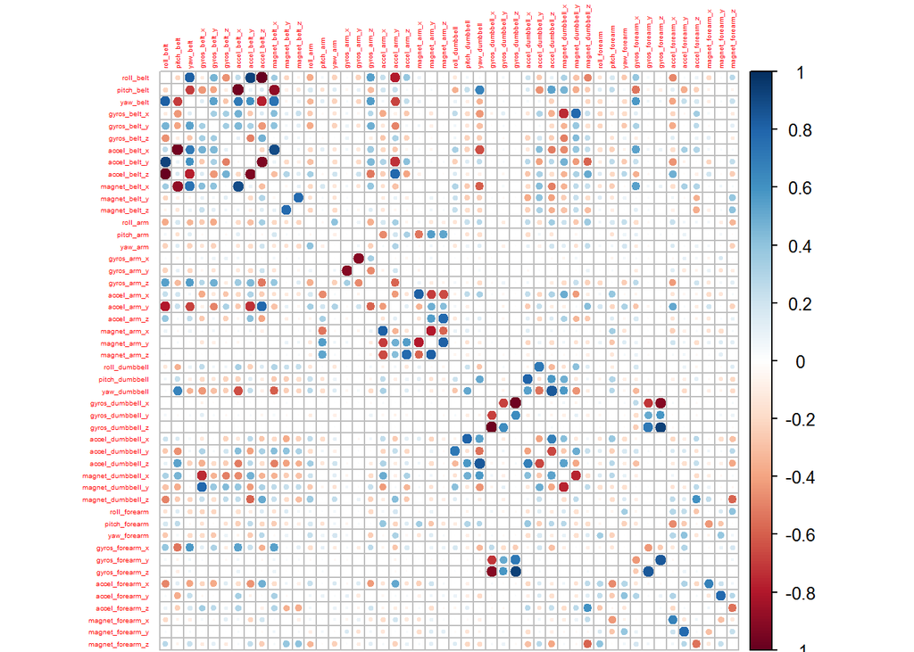

```r
classe_column_num <- dim(training)[[2]];
corMatrix <- cor(training[,-classe_column_num])
diag(corMatrix) <- 0
corrplot(corMatrix,tl.cex=0.3)
```

We can see from the plot that there are number of features highly correlated with each other. In this case, there is a need to use principal component analysis (PCA) to transform the data to a smaller subspace where the new variable are uncorrelated with one another. The preProcess class can apply this transformation by including “pca” in the method argument. Doing this will also force scaling of the predictors

# Training

We have everything we need for training our model. We will use Random Forest algorithm

```r
rfFit <- train(classe~., samples.training, method = "rf", preProcess=c("pca"), trControl = trainControl(method = "cv"))
rfFit$finalModel
```

```
##
## Call:
##  randomForest(x = x, y = y, mtry = param$mtry)
##                Type of random forest: classification
##                      Number of trees: 500
## No. of variables tried at each split: 2
##
##         OOB estimate of  error rate: 2.54%
## Confusion matrix:
##      A    B    C    D    E class.error
## A 3882    8    9    4    3    0.006144
## B   39 2570   41    3    5    0.033108
## C    6   36 2318   34    2    0.032554
## D    4    4   98 2139    7    0.050178
## E    2   13   19   12 2479    0.018218
```

**Expected error**: The model has acceptible estimated OOB error rate of 2.54%

# Model evaluation

To get accurate statisticis about performance of our model we can use confusion matrix.

```r
testing.predictions <- predict(rfFit,samples.testing);
cM <- confusionMatrix(samples.testing$classe, testing.predictions);
cM
```

```
## Confusion Matrix and Statistics
##
##           Reference
## Prediction    A    B    C    D    E
##          A 1665    4    4    1    0
##          B   19 1101   16    0    3
##          C    2    9 1006    6    3
##          D    0    2   47  910    5
##          E    0    5    9    4 1064
##
## Overall Statistics
##
##                Accuracy : 0.976
##                  95% CI : (0.972, 0.98)
##     No Information Rate : 0.286
##     P-Value [Acc > NIR] : <2e-16
##
##                   Kappa : 0.97
##  Mcnemar's Test P-Value : NA
##
## Statistics by Class:
##
##                      Class: A Class: B Class: C Class: D Class: E
## Sensitivity             0.988    0.982    0.930    0.988    0.990
## Specificity             0.998    0.992    0.996    0.989    0.996
## Pos Pred Value          0.995    0.967    0.981    0.944    0.983
## Neg Pred Value          0.995    0.996    0.984    0.998    0.998
## Prevalence              0.286    0.190    0.184    0.156    0.183
## Detection Rate          0.283    0.187    0.171    0.155    0.181
## Detection Prevalence    0.284    0.194    0.174    0.164    0.184
## Balanced Accuracy       0.993    0.987    0.963    0.989    0.993
```

# Final predictions

Finally let’s get our answers for the testing data we were given.

```r
answers <- predict(rfFit,testing);
answers
```

```
##  [1] B A C A A E D B A A B C B A E E A B B B
## Levels: A B C D E
```